# Can We Greatly Predict the Price Movement of Bitcoin?

Bitcoin is a speculative instrument (I hesitate to call it an asset directly as the financial community has not settled on calling it an asset yet) that was created in 2009. It belongs to a family of speculative instruments called **cryptocurrencies** which contain many similar properties: trading occurs over a blockchain database, there is no physical counterpart of this instrument, etc.

In its early days, Bitcoin (hence forth we will refer to it as **BTC**) was a very obscure name and was rarely referred to in the mainstream. However, since 2015, BTC became far more popular as an investment vehicle and many became rich off of it. Since then, many have tried to predict BTC movements and have tried to become rich off of it. However, since the pre-pandemic peak on Dec 17, 2017, BTC became less favourable for the common investor as it smelled like a **speculative trap**. Since BTC did not produce anything in the actual economy, it is not backed by any economic phenomena and hence in the pre-pandemic era, it seemed as though it followed a similar trajectory as the **Tulip Mania** of the 1600s in the Netherlands.

This notebook also serves as fantastic introduction to the data science pipeline, and particularly the applications of this pipeline in a finance setting, as defined by:

1. Data Curation
2. Data Management and Representation
3. Exploratory Data Analysis (and Hypothesis Testing)
4. Machine Learning
5. Generating Insights

Thereby, it is up to you, the reader, as to what to take away from this notebook. It serves a dual purpose: exploring the nature of BTC and introducing you to the overall data science pipeline.

# Set Up

In this notebook, we will be using the following libraries. Because Tensorflow is typically not pre-downloaded in most machines, I have included code below that when executed will download Tensorflow to the current Jupyter Kernel.

```python
!pip install tensorflow
```

[output not shown]

## Importing the Libraries

**pandas** Pandas is a data storage and manipulation library. Data is stored in 2-D dataframes which are similar to excel sheets. For us, we are using pandas dataframes to store the Date, Open Price, High Price, Low Price, Close Price, and Volume data.

**numpy** Numpy is a scientific computing library. Numpy stores data in n-dimensional arrays which are very similar to Matlab's matrices/vectors. Being a scientific computing library, Numpy optimizes computation speed. For us, using the scientific computing stack of numpy is ideal to train any ML model since a lot of computations are bound to occur.

**matplotlib** Matplotlib is a plotting library. For us, we use it to plot any data that we need to observe visually.

**sklearn** Scikit Learn is a popular Machine Learning library that contains, for us, a large number of pre-designed models that whose hyperparameters we can tune and deploy with ease.

**tensorflow** Tensorflow is a popular Deep learning library that contains various functions and modules we can use to design deep networks with relative ease.

**datetime** Datetime is library that allows us to convert string dates into date objects which has greater functionaliity (we can directly compare 2 datetime objects which will return the younger date etc.)

**statsmodels** Statsmodels is a popular statistical library whose OLS functionality we use to generate linear regressions.

```python
import pandas as pd
import numpy as np
import matplotlib.pyplot as plt
import sklearn
import tensorflow as tf
import datetime
from datetime import datetime
from statsmodels.formula.api import ols
```

# Data Collection and Curation

## Nature of Our Datasets

1. **Dataset 1: BTC-USD.csv** Our first dataset (**dataset1**) stored in *BTC-USD.csv* contains the price and volume data of Bitcoin between April 10, 2020 to May 15, 2021.

*BTC-USD.csv* can be retrieved from **https://finance.yahoo.com/quote/BTC-USD/history?period1=1410825600&period2=1621123200&interval=1d&filter=history&frequency=1d&includeAdjustedClose=true**

*BTCUSD_day.csv* can be retrived from **https://www.kaggle.com/prasoonkottarathil/btcinusd?select=BTCUSD_day.csv**

## Loading the Data

```python
dataset1 = pd.read_csv('BTC-USD.csv')
dataset1
```

|  | Date | Open | High | Low | Close | Adj Close | Volume |
| --- | --- | --- | --- | --- | --- | --- | --- |
| 0 | 2020-04-10 | 7303.815430 | 7303.815430 | 6802.475098 | 6865.493164 | 6865.493164 | 4.362284e+10 |
| 1 | 2020-04-11 | 6867.440430 | 6926.069824 | 6789.920898 | 6859.083008 | 6859.083008 | 3.122209e+10 |
| 2 | 2020-04-12 | 6858.067871 | 7119.947266 | 6811.078125 | 6971.091797 | 6971.091797 | 3.575957e+10 |
| 3 | 2020-04-13 | 6965.616699 | 6965.616699 | 6668.259766 | 6845.037598 | 6845.037598 | 3.861931e+10 |
| 4 | 2020-04-14 | 6843.281738 | 6958.557129 | 6793.821289 | 6842.427734 | 6842.427734 | 3.411043e+10 |
| ... | ... | ... | ... | ... | ... | ... | ... |
| 396 | 2021-05-11 | 55847.242188 | 56872.542969 | 54608.652344 | 56704.574219 | 56704.574219 | 6.130840e+10 |
| 397 | 2021-05-12 | 56714.531250 | 57939.363281 | 49150.535156 | 49150.535156 | 49150.535156 | 7.521540e+10 |
| 398 | 2021-05-13 | 49735.433594 | 51330.843750 | 46980.019531 | 49716.191406 | 49716.191406 | 9.672115e+10 |
| 399 | 2021-05-14 | 49682.980469 | 51438.117188 | 48868.578125 | 49880.535156 | 49880.535156 | 5.573750e+10 |
| 400 | 2021-05-15 | NaN | NaN | NaN | NaN | NaN | NaN |

401 rows × 7 columns

```python
dataset2 = pd.read_csv('BTCUSD_day.csv')
dataset2
```

|  | Date | Symbol | Open | High | Low | Close | Volume BTC | Volume USD |
| --- | --- | --- | --- | --- | --- | --- | --- | --- |
| 0 | 2020-04-10 | BTCUSD | 7315.25 | 7315.25 | 7315.25 | 7315.25 | 0.00 | 0.00 |
| 1 | 2020-04-09 | BTCUSD | 7369.60 | 7378.85 | 7115.04 | 7315.25 | 2237.13 | 16310014.53 |
| 2 | 2020-04-08 | BTCUSD | 7201.81 | 7432.23 | 7152.80 | 7369.60 | 2483.60 | 18138080.27 |
| 3 | 2020-04-07 | BTCUSD | 7336.96 | 7468.42 | 7078.00 | 7201.81 | 2333.34 | 17047120.32 |
| 4 | 2020-04-06 | BTCUSD | 6775.21 | 7369.76 | 6771.01 | 7336.96 | 3727.47 | 26533750.17 |
| ... | ... | ... | ... | ... | ... | ... | ... | ... |
| 1642 | 2015-10-12 | BTCUSD | 249.50 | 249.50 | 247.60 | 247.60 | 38.28 | 9493.89 |
| 1643 | 2015-10-11 | BTCUSD | 246.30 | 249.50 | 246.30 | 249.50 | 12.22 | 3021.12 |
| 1644 | 2015-10-10 | BTCUSD | 245.39 | 246.30 | 244.60 | 246.30 | 12.17 | 2984.44 |
| 1645 | 2015-10-09 | BTCUSD | 243.95 | 249.97 | 243.60 | 245.39 | 30.99 | 7651.63 |
| 1646 | 2015-10-08 | BTCUSD | 242.50 | 245.00 | 242.50 | 243.95 | 18.80 | 4595.84 |

1647 rows × 8 columns

# Cleaning the Data

Although our data is relatively well curated with Open, High, Low, and Close prices along with volume data, there are still lingering issues with our datasets.

In this section, we clean up the data s.t. after we can explore the data with ease and eventually train a model to predict prices. This section is broken down into multiple components listed out here:

- Issue 1: Volume Mismatch
- Issue 2: Extraneous Columns and Reverse Order
- Issue 3: Double Entry for April 10th, 2020
- Issue 4: Merging Both Datasets
- Issue 5: Ensuring Type Compatibility
- Issue 6: Dealing with Missing Data

## Issue 1: Volume Mismatch

As we can see above,

**dataset1** consists of the following columns: Date, Open, High, Low, Close, Adjusted Close, and Volume

while,

**dataset2** consists of the following columns: Date, Symbol, Open, High, Low, Close, Volume BTC, Volume USD

There are 2 volumes present in **dataset2**, while 1 volume present in **dataset1**. This is naturally a problem as any predictive model we build will need a singluar definition of volume. Hence, we need to "standardize" which volume is the correct volume.

If we observe closer, we can see that *Volume* as defined in **dataset1** corresponds to *Volume USD* as defined in **dataset2**. Hence, we can clean up this data by removing the BTC volume in dataset2

```python
# Drops the Volume BTC Column
dataset2 = dataset2.drop('Volume BTC', axis=1)

# renames the Volume USD column to Volume
dataset2.rename(columns={"Volume USD" : "Volume"}, inplace=True)

# displays the first 5 rows to see how the data looks now
dataset2.head()
```

|  | Date | Symbol | Open | High | Low | Close | Volume |
| --- | --- | --- | --- | --- | --- | --- | --- |
| 0 | 2020-04-10 | BTCUSD | 7315.25 | 7315.25 | 7315.25 | 7315.25 | 0.00 |
| 1 | 2020-04-09 | BTCUSD | 7369.60 | 7378.85 | 7115.04 | 7315.25 | 16310014.53 |
| 2 | 2020-04-08 | BTCUSD | 7201.81 | 7432.23 | 7152.80 | 7369.60 | 18138080.27 |
| 3 | 2020-04-07 | BTCUSD | 7336.96 | 7468.42 | 7078.00 | 7201.81 | 17047120.32 |
| 4 | 2020-04-06 | BTCUSD | 6775.21 | 7369.76 | 6771.01 | 7336.96 | 26533750.17 |

## Issue 2: Extraneous Columns and Reverse Order

There are 2 primary issues with **datset2**:

- **Symbol** column is an extraneous column. Hence we should remove it.
- the dataset is also in reverse order as compared to **dataset1**. **Dataset1** is in oldest-latest order while this dataset is in latest-oldest order. Hence we should reverse the order so that both are in the same order.

The only issue with **dataset1** is that we have an extraneous column of **Adj. Close** which we need to remove.

```python
# drops the Symbol column
dataset2.drop('Symbol', axis=1, inplace=True)

# reverses the order of the rows s.t. dataset2 is also in oldest-latest order
dataset2 = dataset2.iloc[::-1].reset_index(drop=True)
dataset2
```

|  | Date | Open | High | Low | Close | Volume |
| --- | --- | --- | --- | --- | --- | --- |
| 0 | 2015-10-08 | 242.50 | 245.00 | 242.50 | 243.95 | 4595.84 |
| 1 | 2015-10-09 | 243.95 | 249.97 | 243.60 | 245.39 | 7651.63 |
| 2 | 2015-10-10 | 245.39 | 246.30 | 244.60 | 246.30 | 2984.44 |
| 3 | 2015-10-11 | 246.30 | 249.50 | 246.30 | 249.50 | 3021.12 |
| 4 | 2015-10-12 | 249.50 | 249.50 | 247.60 | 247.60 | 9493.89 |
| ... | ... | ... | ... | ... | ... | ... |
| 1642 | 2020-04-06 | 6775.21 | 7369.76 | 6771.01 | 7336.96 | 26533750.17 |
| 1643 | 2020-04-07 | 7336.96 | 7468.42 | 7078.00 | 7201.81 | 17047120.32 |
| 1644 | 2020-04-08 | 7201.81 | 7432.23 | 7152.80 | 7369.60 | 18138080.27 |
| 1645 | 2020-04-09 | 7369.60 | 7378.85 | 7115.04 | 7315.25 | 16310014.53 |
| 1646 | 2020-04-10 | 7315.25 | 7315.25 | 7315.25 | 7315.25 | 0.00 |

1647 rows × 6 columns

As we can now see, the extraneous column of **Symbol** has been removed and we have reset the order to oldest-latest for **dataset2**

Below, we now drop the **Adj Close** column from **dataset1**

```python
# removes the Adj. Close column
dataset1.drop('Adj Close', axis=1, inplace=True)
dataset1.head()
```

|  | Date | Open | High | Low | Close | Volume |
| --- | --- | --- | --- | --- | --- | --- |
| 0 | 2020-04-10 | 7303.815430 | 7303.815430 | 6802.475098 | 6865.493164 | 4.362284e+10 |
| 1 | 2020-04-11 | 6867.440430 | 6926.069824 | 6789.920898 | 6859.083008 | 3.122209e+10 |
| 2 | 2020-04-12 | 6858.067871 | 7119.947266 | 6811.078125 | 6971.091797 | 3.575957e+10 |
| 3 | 2020-04-13 | 6965.616699 | 6965.616699 | 6668.259766 | 6845.037598 | 3.861931e+10 |
| 4 | 2020-04-14 | 6843.281738 | 6958.557129 | 6793.821289 | 6842.427734 | 3.411043e+10 |

## Issue 3: Last Row Dataset 2

As we can see below, we have 2 copies of the data from April 10th, 2020. Because **dataset2**'s April 10th, 2020 row has volume = 0, we will remove that row as that is illogical.

**NOTE:** Volume = 0 is possible for any trading instrument, however it is highly unlikely given that at the time people were regularly trading BTC hence, it is most likely corrupted data we see with Volume = 0 in **dataset2**. Hence we can go forward and only take **dataset1**'s April 10th, 2020 row.

```python
dataset1
```

|  | Date | Open | High | Low | Close | Volume |
| --- | --- | --- | --- | --- | --- | --- |
| 0 | 2020-04-10 | 7303.815430 | 7303.815430 | 6802.475098 | 6865.493164 | 4.362284e+10 |
| 1 | 2020-04-11 | 6867.440430 | 6926.069824 | 6789.920898 | 6859.083008 | 3.122209e+10 |
| 2 | 2020-04-12 | 6858.067871 | 7119.947266 | 6811.078125 | 6971.091797 | 3.575957e+10 |
| 3 | 2020-04-13 | 6965.616699 | 6965.616699 | 6668.259766 | 6845.037598 | 3.861931e+10 |
| 4 | 2020-04-14 | 6843.281738 | 6958.557129 | 6793.821289 | 6842.427734 | 3.411043e+10 |
| ... | ... | ... | ... | ... | ... | ... |
| 396 | 2021-05-11 | 55847.242188 | 56872.542969 | 54608.652344 | 56704.574219 | 6.130840e+10 |
| 397 | 2021-05-12 | 56714.531250 | 57939.363281 | 49150.535156 | 49150.535156 | 7.521540e+10 |
| 398 | 2021-05-13 | 49735.433594 | 51330.843750 | 46980.019531 | 49716.191406 | 9.672115e+10 |
| 399 | 2021-05-14 | 49682.980469 | 51438.117188 | 48868.578125 | 49880.535156 | 5.573750e+10 |
| 400 | 2021-05-15 | NaN | NaN | NaN | NaN | NaN |

401 rows × 6 columns

```python
dataset2
```

|  | Date | Open | High | Low | Close | Volume |
| --- | --- | --- | --- | --- | --- | --- |
| 0 | 2015-10-08 | 242.50 | 245.00 | 242.50 | 243.95 | 4595.84 |
| 1 | 2015-10-09 | 243.95 | 249.97 | 243.60 | 245.39 | 7651.63 |
| 2 | 2015-10-10 | 245.39 | 246.30 | 244.60 | 246.30 | 2984.44 |
| 3 | 2015-10-11 | 246.30 | 249.50 | 246.30 | 249.50 | 3021.12 |
| 4 | 2015-10-12 | 249.50 | 249.50 | 247.60 | 247.60 | 9493.89 |
| ... | ... | ... | ... | ... | ... | ... |
| 1642 | 2020-04-06 | 6775.21 | 7369.76 | 6771.01 | 7336.96 | 26533750.17 |
| 1643 | 2020-04-07 | 7336.96 | 7468.42 | 7078.00 | 7201.81 | 17047120.32 |
| 1644 | 2020-04-08 | 7201.81 | 7432.23 | 7152.80 | 7369.60 | 18138080.27 |
| 1645 | 2020-04-09 | 7369.60 | 7378.85 | 7115.04 | 7315.25 | 16310014.53 |
| 1646 | 2020-04-10 | 7315.25 | 7315.25 | 7315.25 | 7315.25 | 0.00 |

1647 rows × 6 columns

```python
dataset2.drop(1646, axis=0, inplace=True)
dataset2.tail()
# Observe the 1646 row has been dropped
```

|  | Date | Open | High | Low | Close | Volume |
| --- | --- | --- | --- | --- | --- | --- |
| 1641 | 2020-04-05 | 6870.20 | 6907.90 | 6678.60 | 6775.21 | 8662210.80 |
| 1642 | 2020-04-06 | 6775.21 | 7369.76 | 6771.01 | 7336.96 | 26533750.17 |
| 1643 | 2020-04-07 | 7336.96 | 7468.42 | 7078.00 | 7201.81 | 17047120.32 |
| 1644 | 2020-04-08 | 7201.81 | 7432.23 | 7152.80 | 7369.60 | 18138080.27 |
| 1645 | 2020-04-09 | 7369.60 | 7378.85 | 7115.04 | 7315.25 | 16310014.53 |

As you can see above, we have dropped the 1646th index which corresponded to the April 10th, 2020 row for **dataset2**.

## Issue 4: Merging the Two Datasets

As we want to eventually train a full fledged model, we need to merge our datasets s.t. we only have 1 dataset which we can pass into a model.

Having only 1 dataset is also useful for initial observations of the data's distribution and will help us greatly in our Exploratory Data Analysis.

```python
frames = [dataset2, dataset1]
# merging the two data sets
data = pd.concat(frames).reset_index(drop=True)
data
```

|  | Date | Open | High | Low | Close | Volume |
| --- | --- | --- | --- | --- | --- | --- |
| 0 | 2015-10-08 | 242.500000 | 245.000000 | 242.500000 | 243.950000 | 4.595840e+03 |
| 1 | 2015-10-09 | 243.950000 | 249.970000 | 243.600000 | 245.390000 | 7.651630e+03 |
| 2 | 2015-10-10 | 245.390000 | 246.300000 | 244.600000 | 246.300000 | 2.984440e+03 |
| 3 | 2015-10-11 | 246.300000 | 249.500000 | 246.300000 | 249.500000 | 3.021120e+03 |
| 4 | 2015-10-12 | 249.500000 | 249.500000 | 247.600000 | 247.600000 | 9.493890e+03 |
| ... | ... | ... | ... | ... | ... | ... |
| 2042 | 2021-05-11 | 55847.242188 | 56872.542969 | 54608.652344 | 56704.574219 | 6.130840e+10 |
| 2043 | 2021-05-12 | 56714.531250 | 57939.363281 | 49150.535156 | 49150.535156 | 7.521540e+10 |
| 2044 | 2021-05-13 | 49735.433594 | 51330.843750 | 46980.019531 | 49716.191406 | 9.672115e+10 |
| 2045 | 2021-05-14 | 49682.980469 | 51438.117188 | 48868.578125 | 49880.535156 | 5.573750e+10 |
| 2046 | 2021-05-15 | NaN | NaN | NaN | NaN | NaN |

2047 rows × 6 columns

## Issue 5: Ensuring Type Compatibility

We want to ensure that our Open, High, Low, Close prices and Volume are all numerical values. As shown below, we can see that they are all of numpy.float64 types.

```python
data.dtypes
```

```
Date       object
Open      float64
High      float64
Low       float64
Close     float64
Volume    float64
dtype: object
```

A key fact above is that currently, the Date column is filled with some object type of data, most likely string. We confirm this via:

```python
print(type(data['Date'][0]))
print(type(data['Date'][2040]))
```

```
<class 'str'>
<class 'str'>
```

By this fact, we do want to convert these string values into datetime objects. Datetime objects allow us to access year, month, and day as individual fields, which will save us a lot of headache later as in current form we will have to parse the string to be able access those fields. Effectively, instead of having to parse the string every time to figure out the month, if we preprocess right now and convert all of these strings to datetime objects, it will be easier for us later down the line when we want to know the day, month, or year. Hence, we will convert these string-based dates to datetime objects.

```python
# converts Date column from a Series of strings to a Series of datetime objects
data['Date'] = data['Date'].apply(lambda x: datetime.strptime(x, "%Y-%m-%d"))
type(data['Date'][0])
```

```
pandas._libs.tslibs.timestamps.Timestamp
```

## Issue 6: Missing Data

**Arguably the most important out of all the issues**

We know that there is bound to be data missing in our data set. Rarely in data science do we perfect well curated data, as shown in the last 5 issues that we corrected. Hence we need to explore the missing data and how it is represented as well as ask critically why the data is missing.

The key questions we need to ask regarding the missing data are

- What data is missing?
- How much data is missing
- For what variables is there missing data?
- Are there any underlying correllations in the missing data? (Classifying our missing data as MAR, MCAR, or MNAR)

### Querying the Missing Data

Lets answer the first 3 questions:

- What data is missing?
- How much data is missing?
- For what variables is there missing data?

To answer any of these questions, we need to query this missing data. To be able to query the missing data, we need to know what form this missing data takes. A hint we got in earlier sections is that our missing data might be have taken 2 forms:

- **NaN** -> we see that the last row of the data contains all NaN values
- **0** -> we had to compensate earlier when trying to merge the data sets that dataset2 had its last row have a volume value = 0

Given these properties, we can check where the data is *NaN* and where the data is *0*

```python
# prints locations where data is NaN
data[data.isna().any(axis=1)]
```

|  | Date | Open | High | Low | Close | Volume |
| --- | --- | --- | --- | --- | --- | --- |
| 1653 | 2020-04-17 | NaN | NaN | NaN | NaN | NaN |
| 1828 | 2020-10-09 | NaN | NaN | NaN | NaN | NaN |
| 1831 | 2020-10-12 | NaN | NaN | NaN | NaN | NaN |
| 1832 | 2020-10-13 | NaN | NaN | NaN | NaN | NaN |
| 2046 | 2021-05-15 | NaN | NaN | NaN | NaN | NaN |

```python
# prints locations where data is 0 for Volume
data[data['Volume'] == 0]
```

|  | Date | Open | High | Low | Close | Volume |
| --- | --- | --- | --- | --- | --- | --- |
| 688 | 2017-08-26 | 4371.25 | 4371.25 | 4371.25 | 4371.25 | 0.0 |
| 1039 | 2018-08-12 | 6091.87 | 6091.87 | 6091.87 | 6091.87 | 0.0 |
| 1104 | 2018-10-16 | 6437.66 | 6437.66 | 6428.43 | 6428.43 | 0.0 |

```python
# prints locations where data is 0 for High
data[data['High'] == 0]
```

|  | Date | Open | High | Low | Close | Volume |
| --- | --- | --- | --- | --- | --- | --- |

```python
# prints locations where data is 0 for Low
data[data['Low'] == 0]
```

|  | Date | Open | High | Low | Close | Volume |
| --- | --- | --- | --- | --- | --- | --- |

```python
# prints locations where data is 0 for Open
data[data['Open'] == 0]
```

|  | Date | Open | High | Low | Close | Volume |
| --- | --- | --- | --- | --- | --- | --- |

```python
# prints locations where data is 0 for Close
data[data['Close'] == 0]
```

|  | Date | Open | High | Low | Close | Volume |
| --- | --- | --- | --- | --- | --- | --- |

We can see above that the data is *NaN* for 5 dates across all columns, and the data is 0 for volume for 3 dates. We also see that at any point only volume data is missing with 0 as replacement.

Hence we can answer all of our pertinent questions for this section:

- **What data is missing?** The missing data is listed above. We are missing 5 rows of data where every column has data missing represented by *NaN*. We also have 3 rows of data where only the volume column has data missing and is represented by *0*.
- **How much data is missing?** As mentioned above, we are missing a total of 8 rows of data where 5 rows are fully missing and 3 rows are partially missing
- **For what variables is there missing data?** As mentioned above, we are missing, for 5 rows, all of the price and volume data, while for 3 rows, we are missing just the volume data.

### Hypothesizing Why the Data is Missing

Lets answer our last question now: **Are there any underlying correllations in the missing data? (Classifying our missing data as MAR, MCAR, or MNAR)**

#### The *NaN* Missing Data

When speculating why this trading data is missing, the immediate reason we can suspect is that the missing data is linked to specific holidays.

We can observe this via the string of missing trading data that was replaced by *NaN* between October 9th, 2020 to October 13th, 2020. October 12th, 2020, another missing entry in our data, was Columbus day, and in a lot of markets, they had considered the entire weekend all the way to that Friday to be Columbus day weekend. Hence, there seems to be a strong correllation, and in fact a plausible causation, that the missing data in that interval is due to Columbus Day weekend leading to most traders taking a vacation hence the lack of trading data.

This reasoning is not uncommon in trading data, and often not uncommon in general Time Series Data. An unrelated example would be that the New York Stock Exchange has operating hours of 9:30 - 4:00. Hence if we were analysing price data of a specific stock every minute during a day, we would get quite a few rows with missing data as the stock market is not actively trading at, for example, 3:00 am. This missingness is unrelated with the actual observed variables, but are actually affected by unobserved variables.

Going off this hypothesis, it seems as though the missing data that is *NaN* is uncorrellated with observed trading data, as price and volume are not causing the missingness. Hence, we would classify this missing data as **Missing Completely at Random (MCAR)** as the probability that data is missing is uncorrellated with our values in the data set. Hence we cannot model and can mostly ignore this missing data.

#### The *0* Missing Data

It is unclear exactly why this data is missing. Through cross-referencing other data sources, there is trading volume present on the 3 missing days: 08/26/2017, 08/12/2018, and 10/16/2018.

We can hypothesize that this might just be corrupt data, as there are only 3 occurrences of volume = 0. Although this is a simplestic hypothesis as to why this data is missing, it might be impossible to determine if there is a non-random distribution of why this data is missing as there are very few data points with missing volume values.

Hence, as we can classify this volume data to be **Missing Completely at Random (MCAR)** as well.

### Dealing with the Missing Data

Now that we know we can classify all the missing data as **MCAR**, we can deterimine what to do with this data. There are 3 typical approaches to deal with missing data:

1. Remove the missing data
2. Impute the missing data (replace the missing data)
3. Encode the missing data (tell our model to ignore certain components of the missing data)

#### Dealing with the NaN Data

Because the NaN data has all columns with missing data, we can directly **remove** the missing data as it is likely impossible to encode or impute since we don't have any direct variable value present in the missing data by which we could impute the data (direct being defined as we don't have variable in the missing data that has a value since all of it is missing).

```python
# drops any row with NaN values; axis = 0 -> drops rows
data = data.dropna(axis=0)
# resets indices
data = data.reset_index(drop=True)
data
```

|  | Date | Open | High | Low | Close | Volume |
| --- | --- | --- | --- | --- | --- | --- |
| 0 | 2015-10-08 | 242.500000 | 245.000000 | 242.500000 | 243.950000 | 4.595840e+03 |
| 1 | 2015-10-09 | 243.950000 | 249.970000 | 243.600000 | 245.390000 | 7.651630e+03 |
| 2 | 2015-10-10 | 245.390000 | 246.300000 | 244.600000 | 246.300000 | 2.984440e+03 |
| 3 | 2015-10-11 | 246.300000 | 249.500000 | 246.300000 | 249.500000 | 3.021120e+03 |
| 4 | 2015-10-12 | 249.500000 | 249.500000 | 247.600000 | 247.600000 | 9.493890e+03 |
| ... | ... | ... | ... | ... | ... | ... |
| 2037 | 2021-05-10 | 58250.871094 | 59519.355469 | 54071.457031 | 55859.796875 | 7.177655e+10 |
| 2038 | 2021-05-11 | 55847.242188 | 56872.542969 | 54608.652344 | 56704.574219 | 6.130840e+10 |
| 2039 | 2021-05-12 | 56714.531250 | 57939.363281 | 49150.535156 | 49150.535156 | 7.521540e+10 |
| 2040 | 2021-05-13 | 49735.433594 | 51330.843750 | 46980.019531 | 49716.191406 | 9.672115e+10 |
| 2041 | 2021-05-14 | 49682.980469 | 51438.117188 | 48868.578125 | 49880.535156 | 5.573750e+10 |

2042 rows × 6 columns

#### Dealing with the 0 Data

We can get the missing volume data via online data bases. As such, we will use yahoo and manually impute the data from a manual online query over trying to download another file to fill in the data.

```python
# acquires the new indices where we need to update the 0 volume data since we re-indexed in earlier bloc
# Turns out they are the same, but good practice still to ensure you are updating the correct indices
data[data['Volume'] == 0]
```

|  | Date | Open | High | Low | Close | Volume |
| --- | --- | --- | --- | --- | --- | --- |
| 688 | 2017-08-26 | 4371.25 | 4371.25 | 4371.25 | 4371.25 | 0.0 |
| 1039 | 2018-08-12 | 6091.87 | 6091.87 | 6091.87 | 6091.87 | 0.0 |
| 1104 | 2018-10-16 | 6437.66 | 6437.66 | 6428.43 | 6428.43 | 0.0 |

```python
# Replaces the 0 volume values with values searched up on yahoo
data.at[688, 'Volume'] = 1511609984
data.at[1039, 'Volume'] = 5665250000
data.at[1104, 'Volume'] = 4074800000

# displays whether we still have 0 volume values to ensure we did change the values
data[data['Volume'] == 0]
```

|  | Date | Open | High | Low | Close | Volume |
| --- | --- | --- | --- | --- | --- | --- |

# Full Definition of the Data

Since we have cleaned up the data, lets now give an aggregate definition of the data which we can refer back to moving forward.

1. **Date**: Represents the date on which this data is recorded
2. **Open**: Represents the **starting/opening** price when trading began on a specific day
3. **High**: Represents the **highest** price recorded during trading on a specific trading day
4. **Low**: Represents the **lowest** price recorded during trading on a specific trading day
5. **Close**: Represents the **ending/closing** price when trading began on a specific day
6. **Volume**: Represents the aggregate amount of BTC (measured in USD) that was traded on a specific day

```python
data
```

|  | Date | Open | High | Low | Close | Volume |
| --- | --- | --- | --- | --- | --- | --- |
| 0 | 2015-10-08 | 242.500000 | 245.000000 | 242.500000 | 243.950000 | 4.595840e+03 |
| 1 | 2015-10-09 | 243.950000 | 249.970000 | 243.600000 | 245.390000 | 7.651630e+03 |
| 2 | 2015-10-10 | 245.390000 | 246.300000 | 244.600000 | 246.300000 | 2.984440e+03 |
| 3 | 2015-10-11 | 246.300000 | 249.500000 | 246.300000 | 249.500000 | 3.021120e+03 |
| 4 | 2015-10-12 | 249.500000 | 249.500000 | 247.600000 | 247.600000 | 9.493890e+03 |
| ... | ... | ... | ... | ... | ... | ... |
| 2037 | 2021-05-10 | 58250.871094 | 59519.355469 | 54071.457031 | 55859.796875 | 7.177655e+10 |
| 2038 | 2021-05-11 | 55847.242188 | 56872.542969 | 54608.652344 | 56704.574219 | 6.130840e+10 |
| 2039 | 2021-05-12 | 56714.531250 | 57939.363281 | 49150.535156 | 49150.535156 | 7.521540e+10 |
| 2040 | 2021-05-13 | 49735.433594 | 51330.843750 | 46980.019531 | 49716.191406 | 9.672115e+10 |
| 2041 | 2021-05-14 | 49682.980469 | 51438.117188 | 48868.578125 | 49880.535156 | 5.573750e+10 |

2042 rows × 6 columns

# Exploratory Data Analysis

Lets now try to observe the underlying data distribution. This will provide us insights as to what type of ML system to use, the potential biases, and how to approach overall prediction.

## Visualizing Evolution of BTC Prices

Lets first look at the general progression of BTC Prices over time. Since there are 4 measurements of prices: Open, Low, High, Close, we will plot all 4 as individual lines.

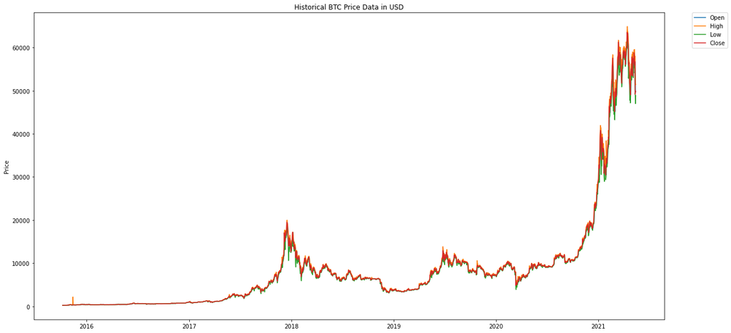

```python
plot_cols = ['Open', 'High', 'Low', 'Close']
# setting size of the plot
plt.figure(figsize=(20,10))
# titling the graph and setting the labels
plt.title('Historical BTC Price Data in USD')
plt.ylabel('Price')
#plotting each price metric
for col in plot_cols:
    y = data[col]
    x = data['Date']
    plt.plot(x, y, label=col)
    plt.legend(bbox_to_anchor=(1.1,1), loc=0, borderaxespad=0)
```

A key fact see here, which might seem obvious for the average trader, is that these prices are heavily correllated with each other. This makes sense as the Open Price is built on the prior day's Close Price, and any High and Low Prices that might be achieved on that are dependent upon the Open Price as we are not going to see massive stochasisity directly from the price data.

Although this may seem like an obvious fact, it is always wise to ensure that any expected correllations you might see in your data actually manifest in EDA.

## Exploring Both Volume and Price

As we can see above, all 4 price metrics roughly match each other. Hence we can choose a singular representative price metric for all 4. We will be choosing **Close** price to be our representative price metric, although you may choose any.

Hence, lets now look at a graph with both volume and price plotted to get a fuller view of the underlying trends.

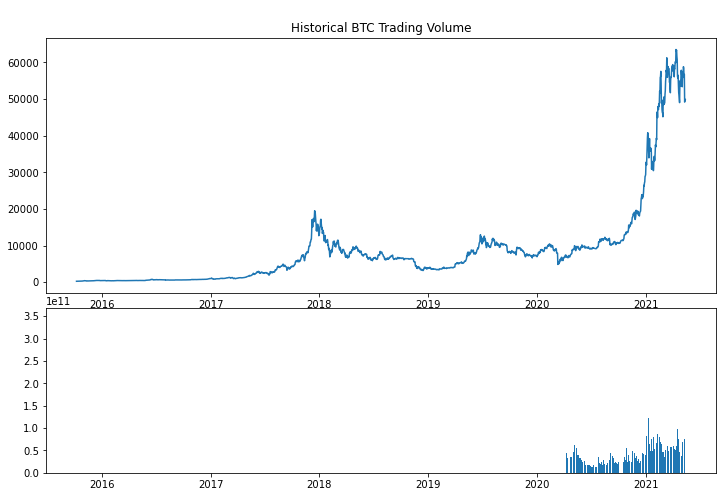

```python
# plotting the top portion which is the Close price
top_plt = plt.subplot2grid((5,4), (0, 0), rowspan=3, colspan=4)
top_plt.plot(data['Date'], data['Close'])
# titling the top half
plt.title('Historical BTC Price Data in USD')
# titling the bottom half
plt.title('\nHistorical BTC Trading Volume')
# plotting the bottom portion which is Volume
bot_plt = plt.subplot2grid((5,4), (3,0), rowspan=3, colspan=4)
bot_plt.bar(data['Date'], data['Volume'])
plt.gcf().set_size_inches(12,8)
```

The key thing to note here is that although there was a price spike in 2018, a lot of the upward price movement in BTC is very much correllated with increased trading activity seen in BTC in the last year (since early 2020). As we are aware, part of this is likely due to the COVID-19 Pandemic as the start of this Volume trend began around March-April-May of 2020 as per the graph.

Lets explore this relationship between Volume and Price by splitting the data set into 2: one before March 11th, 2020 (the day the WHO declared COVID to be a pandemic) and one after. We do this because it is clear that this trading activity picked up during COVID-quarantine, which is an **exogenous variable** within our data. Thereby, we should analyze the underlying distribution of Volume and Price data via splitting this data set s.t. we do not observe the effect of the **COVID-19 Exogenous Variable** in our statistical data exploration.

### Observing Volume vs. Close Price BEFORE WHO Declaration of COVID-19 to be a Pandemic

The easiest way to observe a relationship between variables is to estimate a linear regression between the 2 variables. Hence, we will try that.

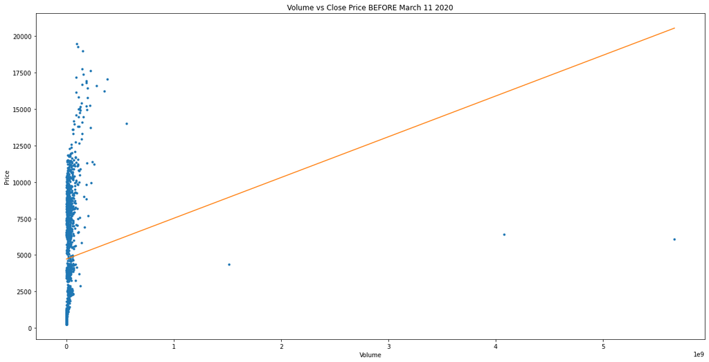

```python
# generating the data up until March 11th 2020, the day the WHO declared COVID-19 to be a pandemic
# we also pass in the data sorted by volume
uptill_2020 = data[data['Date'] < datetime(2020, 3, 11)].sort_values('Volume')
x_uptill = uptill_2020['Volume']
y_uptill = uptill_2020['Close']
# modelling a linear regression for the data up till March 11th, 2020
# generates estimates -> m = slope parameter, b = intercept
m_b4, b_b4 = np.polyfit(x=x_uptill,y=y_uptill,deg=1)
# plotting the actual data
plt.figure(figsize=(20,10))
plt.title('Volume vs Close Price BEFORE March 11 2020')
plt.xlabel('Volume')
plt.ylabel('Price')
plt.plot(x_uptill, y_uptill, '.', x_uptill, m_b4 * x_uptill + b_b4)
```

**NOTE:** The linear regression shown above is clearly deviating from a best fit line due to a few outliers.

The common conviction among many statisticians seeing this would be to remove the outliers and re-estimate the linear regression. However, we will **not** do this. That is because these outliers are important to the price and volume movement of BTC and warrant further study. We know by looking at the volume data, BTC was relatively **illiquid** (meaning that it was not easily bought and sold) up until the COVID-19 Pandemic, and hence these volume spikes have certain casual factors we need to study.

Lets instead try to plot this in a time series graph.

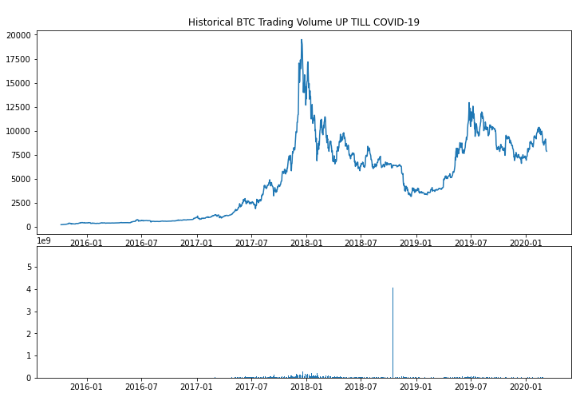

```python
# resorting values back to by date
uptill_2020 = uptill_2020.sort_values('Date')
# plotting the top portion which is the Close price
top_plt = plt.subplot2grid((5,4), (0, 0), rowspan=3, colspan=4)
top_plt.plot(uptill_2020['Date'], uptill_2020['Close'])
# titling the top half
plt.title('Historical BTC Price Data in USD UP TILL COVID-19')
# titling the bottom half
plt.title('\nHistorical BTC Trading Volume UP TILL COVID-19')
# plotting the bottom portion which is Volume
bot_plt = plt.subplot2grid((5,4), (3,0), rowspan=3, colspan=4)
bot_plt.bar(uptill_2020['Date'], uptill_2020['Volume'])
plt.gcf().set_size_inches(12,8)
```

**NOTE:** the volume spike between 2018-07 and 2019-01

It seems as though that volume spike is correllated with a drop off in BTC price. Here we can see that there seems to be somewhat of an underlying correllation between Volume and Price.

### Generating the Volume vs. Close Price Regression AFTER WHO Declaration of COVID-19 to be a Pandemic

As earlier, lets look at the relationship between Volume and Price through the lens of a regression first.

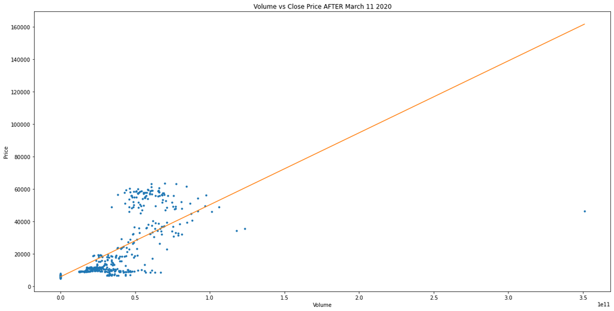

```python
# generating data after March 11th as that is when we knew we were in a pandemic
# we also pass in the data sorted by volume
after = data[data['Date'] >= datetime(2020,3,11)].sort_values('Volume')
x_after = after['Volume']
y_after = after['Close']
# modelling a linear regression for the data after March 11th, 2020
m_af,b_af = np.polyfit(x=x_after,y=y_after,deg=1)
# plotting the actual data
plt.figure(figsize=(20,10))
plt.title('Volume vs Close Price AFTER March 11 2020')
plt.xlabel('Volume')
plt.ylabel('Price')
plt.plot(x_after, y_after, '.', x_after, m_af * x_after + b_af)
```

**NOTE:** This regression above is clearly deviating from a best fit line due to a few outliers.

As earlier, we will not try to re-estimate the linear regression by removing the outliers since these deviations require study due to their magnitude. As before, we will instead plot a time series graph of volume and price.

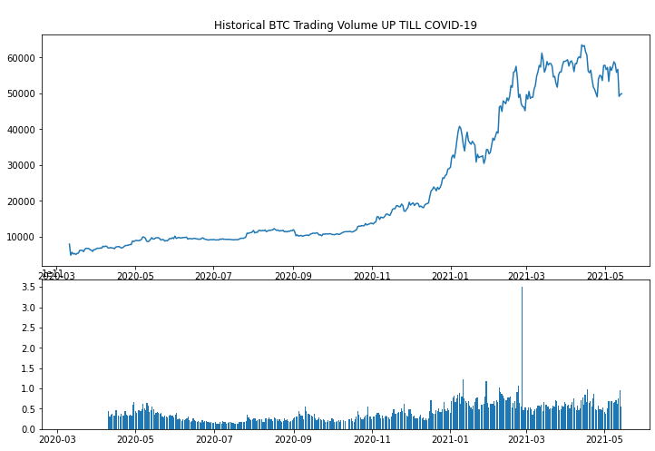

```python
# resorting values back to by date
after = after.sort_values('Date')
# plotting the top portion which is the Close price
top_plt = plt.subplot2grid((5,4), (0, 0), rowspan=3, colspan=4)
top_plt.plot(after['Date'], after['Close'])
# titling the top half
plt.title('Historical BTC Price Data in USD UP TILL COVID-19')
# titling the bottom half
plt.title('\nHistorical BTC Trading Volume UP TILL COVID-19')
# plotting the bottom portion which is Volume
bot_plt = plt.subplot2grid((5,4), (3,0), rowspan=3, colspan=4)
bot_plt.bar(after['Date'], after['Volume'])
plt.gcf().set_size_inches(12,8)
```

**NOTE:** The large volume spike near 2021-03 timestamp

### Hypothesis Testing of Price and Volume Relationship

Lets conduct Hypothesis testing to cement the relationship between Price and Volume and to measure its statistical significance.

Our **null hypothesis** will be that volume has no effect on price, and hence our **alternative hypothesis** will be that volume may have an effect on price.

```python
uptill_2020 = uptill_2020.sort_values('Volume')
model_uptill = ols(formula='Close~Volume', data=uptill_2020).fit()
print(model_uptill.summary())
```

```
                            OLS Regression Results
==============================================================================
Dep. Variable:                  Close   R-squared:                       0.016
Model:                            OLS   Adj. R-squared:                  0.016
Method:                 Least Squares   F-statistic:                     26.57
Date:                Mon, 17 May 2021   Prob (F-statistic):           2.86e-07
Time:                        14:47:09   Log-Likelihood:                -15669.
No. Observations:                1616   AIC:                         3.134e+04
Df Residuals:                    1614   BIC:                         3.135e+04
Df Model:                           1
Covariance Type:            nonrobust
==============================================================================
                 coef    std err          t      P>|t|      [0.025      0.975]
------------------------------------------------------------------------------
Intercept   4719.4076     99.084     47.630      0.000    4525.061    4913.754
Volume      2.796e-06   5.42e-07      5.155      0.000    1.73e-06    3.86e-06
==============================================================================
Omnibus:                       79.708   Durbin-Watson:                   0.835
Prob(Omnibus):                  0.000   Jarque-Bera (JB):               83.339
Skew:                           0.525   Prob(JB):                     8.00e-19
Kurtosis:                       2.634   Cond. No.                     1.85e+08
==============================================================================

Notes:
[1] Standard Errors assume that the covariance matrix of the errors is correctly specified.
[2] The condition number is large, 1.85e+08. This might indicate that there are
strong multicollinearity or other numerical problems.
```

As shown above, since the p-value is 0 for the Volume parameter, it suggests that it is nigh impossible for this sample of Volume-Price pairs to exist given that Volume has no effect on Price. Hence, we can conclude that in the pre-pandemic phase, volume did have an apparent effect on Price and hence it is **statistically significant** thereby we **reject the null hypothesis in favour of the alternative hypothesis**.

```python
after = after.sort_values('Volume')
model_after = ols(formula='Close~Volume', data=after).fit()
print(model_after.summary())
```

```
                            OLS Regression Results
==============================================================================
Dep. Variable:                  Close   R-squared:                       0.417
Model:                            OLS   Adj. R-squared:                  0.415
Method:                 Least Squares   F-statistic:                     302.7
Date:                Mon, 17 May 2021   Prob (F-statistic):           1.48e-51
Time:                        14:47:57   Log-Likelihood:                -4677.3
No. Observations:                 426   AIC:                             9359.
Df Residuals:                     424   BIC:                             9367.
Df Model:                           1
Covariance Type:            nonrobust
==============================================================================
                 coef    std err          t      P>|t|      [0.025      0.975]
------------------------------------------------------------------------------
Intercept   5969.4087   1216.329      4.908      0.000    3578.623    8360.194
Volume      4.432e-07   2.55e-08     17.398      0.000    3.93e-07    4.93e-07
==============================================================================
Omnibus:                       99.554   Durbin-Watson:                   1.225
Prob(Omnibus):                  0.000   Jarque-Bera (JB):             1618.068
Skew:                          -0.481   Prob(JB):                         0.00
Kurtosis:                      12.499   Cond. No.                     8.43e+10
==============================================================================

Notes:
[1] Standard Errors assume that the covariance matrix of the errors is correctly specified.
[2] The condition number is large, 8.43e+10. This might indicate that there are
strong multicollinearity or other numerical problems.
```

Similarly, as shown above, since the p-value is 0 for the volume parameter, it suggests that it is nigh impossible for this sample of Volume-Price pairs to exist given that Volume has no effect on Price. Hence, we can conclude that in the pandemic phase, volume did have an apparent effect on Price and hence it is **statistically significant** thereby we **reject the null hypothesis in favour of the alternative hypothesis**.

## Observing the Relationship Between Price Change and Volume

Another key variable we want to observe is the daily percentage change in price from open to close. This variale has an important statistical implication: if we observe this variable to be **stationary** about a 0 mean, then we know that BTC evolves in a cyclic fashion, and in contrast if we observe this variable to be **non-stationary**, then we know that BTC is a stochastic variable that cannot be predicted via determining where we are in the cycle.

Hence, lets visualize the %Δ in price daily data.

```python
# saving the daily price changes in percentage format in a new column
data['DailyChange'] = ((data['Close'] - data['Open'])/data['Open']) * 100
data['DailyChange']
```

```
0        0.597938
1        0.590285
2        0.370838
3        1.299229
4       -0.761523
          ...
2037    -4.104787
2038     1.535138
2039   -13.336963
2040    -0.038689
2041     0.397631
Name: DailyChange, Length: 2042, dtype: float64
```

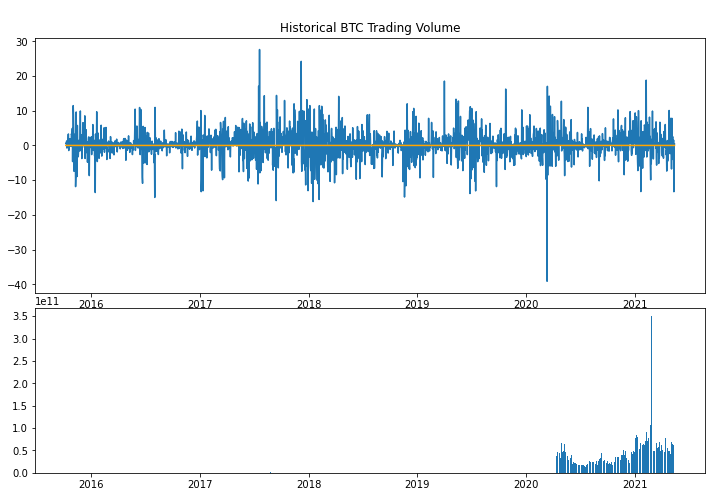

```python
# displaying the daily price change
# plotting the top portion which is the daily price change
top_plt = plt.subplot2grid((5,4), (0, 0), rowspan=3, colspan=4)
# creates an x-axis line
horiz_line_data = np.array([0 for i in range(len(data['Date']))])
top_plt.plot(data['Date'], data['DailyChange'])
#plots the x-axis line
top_plt.plot(data['Date'], horiz_line_data, 'orange')
# titling the top half
plt.title('Historical BTC Price Change in Percentage Change')
# titling the bottom half
plt.title('\nHistorical BTC Trading Volume')
# plotting the bottom portion which is Volume
bot_plt = plt.subplot2grid((5,4), (3,0), rowspan=3, colspan=4)
bot_plt.bar(data['Date'], data['Volume'])
plt.gcf().set_size_inches(12,8)
```

As we can see above, there does seem to be a degree of stationarity present in the percentage change data up until the pandemic, after which there seems to be a large degree of non-stationarity present.

Lets now try to measure the relationship between volume and price change. We will use volume as our explanatory variable for the sake of consistency, however you can use either or. The important facet of this statistical analysis is to observe *whether* a relationship does in fact exist between the 2 variables, not so much the predictive power of the regression or its exact accuracy.

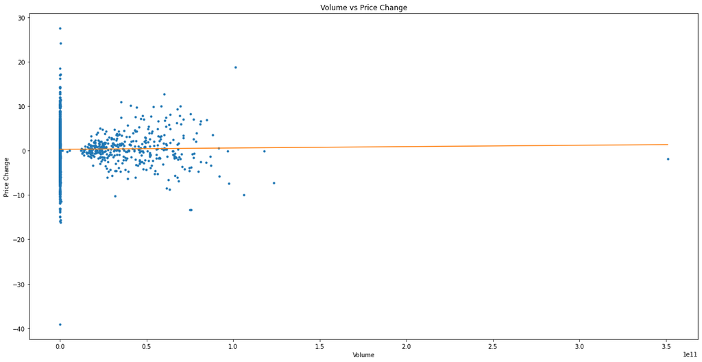

```python
clone = data.sort_values('Volume')
x = clone['Volume']
y = clone['DailyChange']
# modelling a linear regression for the data after March 11th, 2020
m,b = np.polyfit(x=x,y=y,deg=1)
# plotting the actual data
plt.figure(figsize=(20,10))
plt.title('Volume vs Price Change')
plt.xlabel('Volume')
plt.ylabel('Price Change')
plt.plot(x, y, '.', x, m * x + b)
plt.show()
```

**NOTE:** Interestingly, there seems to be a **lack** of a relationship between daily volume and price change per the naked eye. The line is near horizontal and it seems as though the OLS regression almost defaulted to a mean line as the derived OLS Regression might have been extremely poor at explaining the variation (R-squared).

### Hypothesis Testing the Relationship

Noting from earlier, the graph does seem to suggest that **PriceChange** and **Volume** are not correllated. Lets further confirm this hypothesis via hypothesis testing.

We will classify our **null hypothesis** as there exists no correllation between **PriceChange** and **Volume** and our **alternative hypothesis** as there exists a correllation between **PriceChange** and **Volume**.

```python
model = ols(formula='DailyChange~Volume', data=data).fit()
print(model.summary())
```

```
                            OLS Regression Results
==============================================================================
Dep. Variable:            DailyChange   R-squared:                       0.000
Model:                            OLS   Adj. R-squared:                 -0.000
Method:                 Least Squares   F-statistic:                    0.4736
Date:                Mon, 17 May 2021   Prob (F-statistic):              0.491
Time:                        18:23:15   Log-Likelihood:                -5747.7
No. Observations:                2042   AIC:                         1.150e+04
Df Residuals:                    2040   BIC:                         1.151e+04
Df Model:                           1
Covariance Type:            nonrobust
==============================================================================
                 coef    std err          t      P>|t|      [0.025      0.975]
------------------------------------------------------------------------------
Intercept      0.3118      0.097      3.229      0.001       0.122       0.501
Volume      3.047e-12   4.43e-12      0.688      0.491   -5.63e-12    1.17e-11
==============================================================================
Omnibus:                      332.396   Durbin-Watson:                   2.100
Prob(Omnibus):                  0.000   Jarque-Bera (JB):             5722.980
Skew:                          -0.135   Prob(JB):                         0.00
Kurtosis:                      11.197   Cond. No.                     2.36e+10
==============================================================================

Notes:
[1] Standard Errors assume that the covariance matrix of the errors is correctly specified.
[2] The condition number is large, 2.36e+10. This might indicate that there are
strong multicollinearity or other numerical problems.
```

As we can see above, the p-value for the **Volume** parameter is 0.491 implying that there is almost a 50% chance that we could acquire a sample such as this and get a **Volume** estimator to be 3.047e-12 while the true **Volume** parameter is in fact 0, meaning that there is no correllation between **Volume** and **PriceChange**. This p-value is greater than alpha = 10%, meaning that we **fail to reject the null**, meaning that there is a very high likelihood that **Volume** and **DailyChange** are in fact **not correllated**.

# Machine Learning

Moving forward, we can now conduct a degree of Machine Learning on the underlying data distribution.

## Describing the Problem

Using 0 time lags, we saw that there was a correllation between Closing Price and Volume, and there seemed to lack a correllation between Daily Price Change and Volume. However, as this is time series data, there might exist underlying time lagged correllations between variables. In our EDA, we did not explore that as we are unsure about which lags are actually correllated, and using AIC/BIC is outside the scope of the analysis typically performed in an EDA section.

Typically when building an ML model, we need to figure out what we are trying to optimize. Since the purpose of this notebook is to make a model that can generate profits, we can split this problem via a greedy algorthimic paradigm: we will use a greedy rule saying that if we optimize daily trading profits, we will optimize profits in the long run. That is to say, we will build an ML model that predicts whether BTC prices are going to **close lower than open** or **close higher than open**.

When we **close lower than open**, a key trading move we would make is to *short* BTC, that is to bet against the instrument via borrowing BTC from a broker, selling them, and then buying them back at a future date at hopefully a lower price.

When we **close higher than open**, a key trading move we would make is to *long* BTC, that iis to bet for the instrument via buying BTC from a broker, holding it, and then selling them for a profit.

Thereby, if we can predict whether the daily shift in prices is going lower or higher (a **binary classification problem**) measured by a positive or negative difference between the opening and closing price, then we can use this model to make trading decisions as to whether to buy or short every day at the opening price.

## Pursing a Full ML Model

Due to time constraints as I did this entire project myself, I was unable to construct a full Neural Network to execute this binary classification. Although I dabbled in other ML models, I realised that ideally, we would use Neural Networks for probability precision. I have included my game plan to actually build out a full network.

1. If I had a few more days to work on this, I would build out a Fully Connected Neural Network (ie no convolution filters etc.) that would have intermediate Leaky ReLU activations, a final output activation of sigmoid, and use a Binary Cross Entropy Loss function to train my network. This works out very well since ideally we are trying to predict whether price movement will be positive or negative on a given day, hence, using sigmoid as our last activation would produce probabilities whether a given day belongs to a positive class (with positive price movement) or a negative class (with negative price movement). Interemediate Leaky ReLU activations are there to prevent neuron saturation in our intermediate Fully Connected layers (as ReLU can kill neurons through saturation). Binary Cross Entropy Loss makes sense as we are determining classification between 2 classes and this loss function is standard to use in this type of binary classification problem.
1. If I had a month more to work on this, I would shift to a different type of Neural Network which might actually function better after building out the earlier design. I would enhance my features into 2-D spectogram images of price data and volume, and I would feed those values into a Convolutional Neural Network using the standard paradigms of starting with small and fewer filters, and then moving to large and a greater number of filters. I would naturally use dropout and max pooling to assist with dimesnionality reduction, spatial invariance (in our application here can be referred to as temporal invariance), and generalization. I would also use skip-connections, like how ResNet did it, to ensure no gradient decay occurs, and after training I would test this network's performance as compared to the earlier built network.

For either time frame, the main metric by which I would measure success would be validation accuracy in the binary classification, and then deploying this into the "wild" for a moonth to see how it functions against incoming data (which we would similarly classify this as a test set). If accuracy in price movement predictions are above 70%, I would consider either network to have a pretty good performance.

# Net Insights

In measuring whether daily price movement is related to volume, we came across the fact that daily price changes are in fact not that correllated with volume. It also seems as though price changes were some what **stationary** prior to the pandemic, but ever since the pandemic started, daily price changes have entered into a **non-stationary** epoch.

**NOTE:** However, both of these analyses should have an astrix next to them as we did not measure lagged correllation. There is a real possibility that lagged variables in our data set are actually correllated which can speak greater to our distribution. In building an actual ML model, using lagged variables would be essential as we are in many aspects trying to predict future price movements based on past price movements.

I hope by reading this notebook you have learned a greater bit of detail about the underlying statistical distribution of BTC, and it helps you in your own projects related to data science applications in finance. I also hope that seeing a full data science pipeline consisting of

1. Data Curation
2. Data Management and Representation
3. Exploratory Data Analysis (and Hypothesis Testing)
4. Machine Learning
5. Generating Insights allows you greater insight as to what a typical data science project actually looks like. I would highly recommend to you, the reader, that you re-read various portions of this notebook as I understand it is a lot of code and text. A key insight to understand about data science is that in many ways it is just studying statistics. We are always trying to observe the underlying data distribution of our sample, and using that to gain insights about what the population distribution might look like. However, unlike studying statistics, our primary goal is almost always to find some way to gain value out of statistical insights, there is always a grander purpose.

As always, thank you so much for reading this!

The used data sets can be found here:

*BTC-USD.csv* can be retrieved from **https://finance.yahoo.com/quote/BTC-USD/history?period1=1410825600&period2=1621123200&interval=1d&filter=history&frequency=1d&includeAdjustedClose=true**

*BTCUSD_day.csv* can be retrived from **https://www.kaggle.com/prasoonkottarathil/btcinusd?select=BTCUSD_day.csv**